# Bookings(in AUD) Exploration by Heki Wong

# clear data

**Remove all duplicate row**

```
## [1] 88356    30
```

Suppose the date of booking is earlier than date of flight and the currency is AUD, i.e.numberOfDay >= 0 and Pnr.Curr.Code==‘AUD’ .Also , there is no duplicated RLOC(duplicated data). 850 rows is removed from the dataset. After cleared data, there is 88356 rows

**create some variable**

I create three variables for finding net revenue/passenger, fare/ passenger, because I am to know this information for each passenger , not for each transaction. i.e.
$$netPerPerson = Net.Net.Rev/Pnr.Pax.Count$$
$$farePerPerson = Pnr.Fare.Amt/Pnr.Pax.Count$$

There is many missing data in netPerPerson column. It cannot find the the ratio of fare to net revenue.

**Remove all NA in Net revenue/Person and create a variable**

$$fare_to_net = farePerPerson /netPerPerson$$
There is so many data removed.

# Univariate Analysis

### What is the structure of your dataset?

[1] “Pnr.Creat.Date”(the date of create booking) [2] “month_pnr_create”(the month of create booking) [3] “Rloc” ( the reference number of booking)  
[4] “Bkg.User.Id” [5] “Collect.Method” (only e-ticket)  
[6] “Curr.First.Dep.Apt”  
[7] “numberOfDay” ( number of days between date of create booking and date of departure)  
[8] “month_dep” (the month of departure)  
[9] “from_1st” (the 1st city of departure)  
[10] “to_1st” (the 1st city of arrival)  
[11] “from_2nd” (the 2nd city of departure)  
[12] “to_2nd” (the 2nd city of arrival) [13] “from_3rd” (the 3rd city of departure)  
[14] “to_3rd” (the 3rd city of arrival)  
[15] “destination”  
[16] “type” (one-way/return way/ multi-way)  
[17] “Season” (the season of departure  
[18] “Curr.First.Dep.Date”  
[19] “Pnr.Pax.Count” (the number of passengers and companions in each booking)  
[20] “Lang” (language shown on website)  
[21] “Pnr.Curr.Code”  
[22] “Pnr.Fare.Amt” (the amount of Fare in AUD)  
[23] “Bkg.Subclass”  
[24] “Bkg_Subclass” (the booking subclass)  
[25] “Net.Net.Rev” (the net revenue)  
[26] “Sales.Promo”  
[27] “first_ticket_O”  
[28] “first_ticket_D”  
[29] “Route”  
[30] “Pnr.Creat.Pseudo.City.Code”

The variables Lang, Destination, and Bkg_Subclass, are ordered factor variables with the following levels.

**Lang(the language shown on website)**: “CN” “DE” “FR” “GB” “ID” “IT” “JP” “KO” “KR” “NL” “RE” “RU” “TH” “TW”

**Destination**: “ADL” “AMS” “BKK” “BLR” “BNE” “BOM” “BOS” “CAN” “CCU” “CDG” “CEB” “CGK” “CGO” “CJU” “CKG” “CMB” “CNS” “CNX” “CPT” “CRK” “CSX” “CTS” “CTU” “DAC” “DAD” “DEL” “DFW” “DLC” “DME” “DOH” “DPS” “DUR” “DUS” “DXB” “EWR” “FCO” “FOC” “FRA” “FUK” “HAK” “HAN” “HGH” “HKG” “HKT” “HND” “HYD” “ICN” “JFK” “JMU” “JNB” “KHH” “KIX” “KMG” “KTM” “KUL” “KWL” “LAX” “LHR” “MAA” “MAD” “MAN” “MEL” “MLE” “MNL” “MXP” “NGB” “NGO” “NKG” “NRT” “OKA” “ORD” “PEK” “PER” “PNH” “PUS” “PVG” “RMQ” “RUH” “SFO” “SGN” “SHA” “SIN” “SYD” “SYX” “TAO” “TPE” “TSN” “VVO” “WNZ” “WUH” “XIY” “XMN” “YVR” “YYZ” “ZRH”

**Bkg_Subclass** : (best) —————-> (worst) 1) First Class (Flex): F, 2) Business Class : J, C, D, I 3) Premium Economy : W, R, E 4) Economy Class (Standard/flex) : Y, B, H, K, M, L, V 5) Economy Class(Special) : S, N, Q 6) Economy Class(Supersaver): T,U

Other observations: Most passengers buy return tickets flight from HKG in English version. For each transaction , the median of the number of passenger is one. The amount of fare from AUD 0 to AUD 33,517.4 There is 61505 is return ticket. Some of transaction duplicate that the number of RLOC is more than one.

# Final Plots and Summary

### Plot One

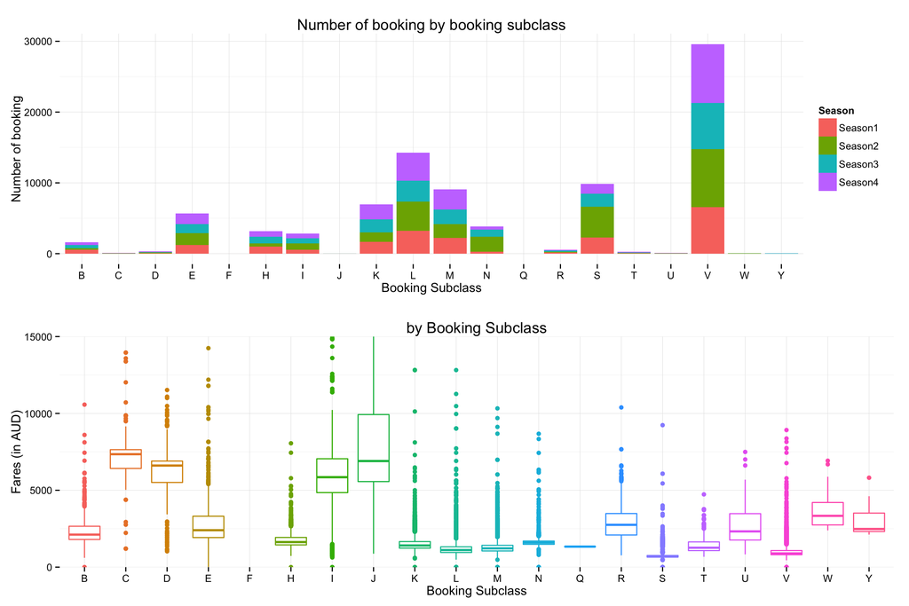

### Plot Two

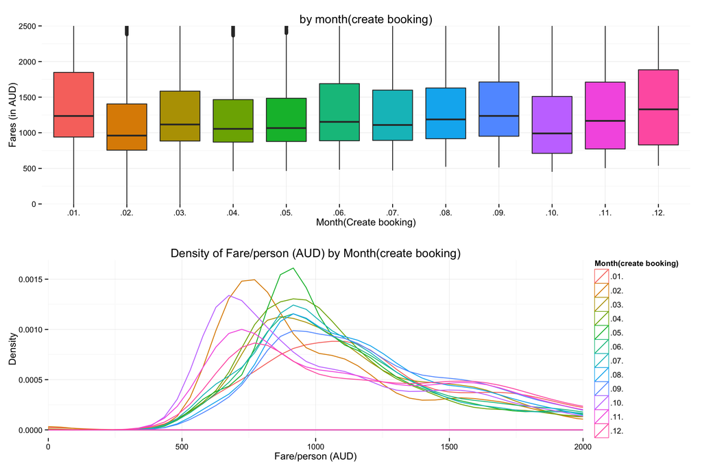

### Plot three

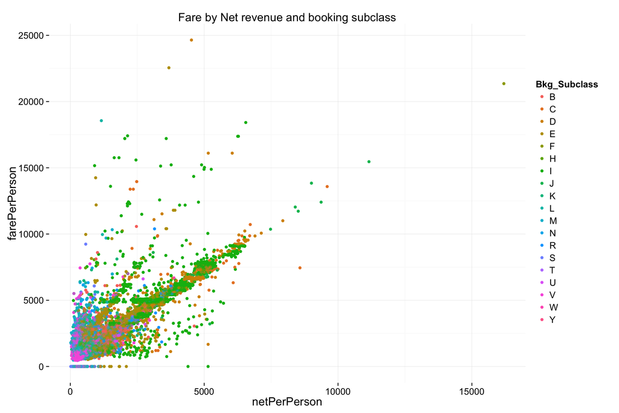

### Description Three

This graph shows the relationship between fare and net revenue booking subclass.Obviously ,the price of fare is higher, the net revenue is higher. Also, there are two recognized lines on the graph that means there are at least two formula for calculate fare by net revenue for different situations.

# Reflection